# CA2-EP0302FT02-P2340656-YeYintAung

Name = Ye Yint Aung Admission Number = 2340656

Data Set 1 link = ( Refugee by country or territory of origin) = https://data.worldbank.org/indicator/SM.POP.REFG.OR

Data Set 2 link = ( Refugee by country or territory of asylum) = https://data.worldbank.org/indicator/SM.POP.REFG

Data Set 3 link = ( ResaleflatpricesbasedonregistrationdatefromJan2017onwards ) = https://beta.data.gov.sg/collections/189/datasets/d_8b84c4ee58e3cfc0ece0d773c8ca6abc/view

Data Set 3 link = ( ResaleflatpricesbasedonregistrationdatefromJan2017onwards ) = https://beta.data.gov.sg/collections/317/view

# Reseacrh Question 1

How does the distribution of refugees vary across countries of asylum and origin, and what patterns or correlations can be identified in the relationship between these two variables?

# RQ 1.1

The following code snippets will generate comprehensive information from the two datasets that I intend to utilize in addressing the aforementioned research question.

```python
import pandas as pd
import numpy as np
import seaborn as sns
import matplotlib.pyplot as plt

# File paths for asylum and origin datasets
asylumFilePath = 'Refugee Population by country or territory of Asylum/refugee-population-by-territory-or-country-of-asylum.csv'
originFilePath = 'Refugee Population by country or territory of Origin/refugee-population-by-territory-or-country-of-origin.csv'

# Read the data from the CSV files
dfAsylum = pd.read_csv(asylumFilePath)
dfOrigin = pd.read_csv(originFilePath)

# Check if the DataFrame for countries by asylum is not empty
if not countryByAsylum.empty:
    # Display header for asylum dataset
    print(f'{"*"*120}')
    print(f'{("Refugee population by territory or country of ASYLUM"):^120}')
    print(f'{"*"*120}')

    # Display loading success message
    print(f'Successfully loaded data from {asylumFilePath}')

    # Display shape, index, column names, non-null values count, and data types
    print(f'Shape of the dataset for countries or territories by asylum: {countryByAsylum.shape}\n')
    print(f'Index of the dataset: {countryByAsylum.index}\n')
    print(f'Column names:\n{countryByAsylum.columns}\n')

    non_na_count = countryByAsylum.count()
    print(f'Total number of non-null values in the dataset:\n{non_na_count}\n')

    print(f'Data types of each column:\n{countryByAsylum.dtypes}\n')

    print(f'Statistical summary of this data set:\n{countryByAsylum.describe()}')
    # Displaying a small part of the dataset
    print(f'First 5 rows of the dataset:\n{countryByAsylum.head()}\n\n')

# Check if the DataFrame for countries by origin is not empty
if not countryByOrigin.empty:
    # Display header for origin dataset
    print(f'{"*"*120}')
    print(f'{("Refugee population by territory or country of ORIGIN"):^120}')
    print(f'{"*"*120}')

    # Display loading success message
    print(f'Successfully loaded data from {originFilePath}')

    # Display shape, index, column names, non-null values count, and data types
    print(f'Shape of the dataset for countries or territories by origin: {countryByOrigin.shape}\n')
    print(f'Index of the dataset: {countryByOrigin.index}\n')
    print(f'Column names:\n{countryByOrigin.columns}\n')

    non_na_count = countryByOrigin.count()
    print(f'Total number of non-null values in the dataset:\n{non_na_count}\n')

    print(f'Data types of each column:\n{countryByOrigin.dtypes}\n')

    print(f'Statistical summary of this data set:\n{countryByOrigin.describe()}')
    # Displaying a small part of the dataset
    print(f'First 5 rows of the dataset:\n{countryByOrigin.head()}')

print(f'\nThe date in these two data sets start from {dfAsylum.columns[4]} to {dfAsylum.columns[-1]}')
```

[output not shown]

[output cut: 257 more lines]

```
Angola           8,388.0     8,292.0     8,243.0     8,176.0     8,196.0
Albania         11,060.0    12,168.0    13,512.0    15,027.0    15,523.0
Andorra              0.0         0.0         0.0         0.0         0.0

                    2021        2022       Row_Sum            Row_Mean
Country Name
Aruba                0.0         0.0           0.0                -0.0
Afghanistan  2,712,869.0 5,661,675.0 147,999,444.0 3,363,623.727272727
Angola          11,403.0    11,751.0  17,763,467.0 281,959.79365079367
Albania         19,847.0    20,847.0     395,176.0  6,813.379310344828
Andorra              0.0         5.0          92.0   6.571428571428571

[5 rows x 65 columns]

The date in these two data sets start from 1960 to 2022
```

# Getting countries code from pycountry library to filter the data of countries from territpries

```python
!pip install pycountry

import pycountry

# Get all countries
country_list = list(pycountry.countries)

# Create a list to store country codes
country_codes = []
country_names = []

# Populate the list with country codes
for country in country_list:
    country_codes.append(country.alpha_3)
    country_names.append(country.name)

# Print the list of country codes
print(country_codes)
print('*'*120)
print(country_names)
```

```
['ABW', 'AFG', 'AGO', 'AIA', 'ALA', 'ALB', 'AND', 'ARE', 'ARG', 'ARM', 'ASM', 'ATA', 'ATF', 'ATG', 'AUS', 'AUT', 'AZE', 'BDI', 'BEL', 'BEN', 'BES', 'BFA', 'BGD', 'BGR', 'BHR', 'BHS', 'BIH', 'BLM', 'BLR', 'BLZ', 'BMU', 'BOL', 'BRA', 'BRB', 'BRN', 'BTN', 'BVT', 'BWA', 'CAF', 'CAN', 'CCK', 'CHE', 'CHL'…
['Aruba', 'Afghanistan', 'Angola', 'Anguilla', 'Åland Islands', 'Albania', 'Andorra', 'United Arab Emirates', 'Argentina', 'Armenia', 'American Samoa', 'Antarctica', 'French Southern Territories', 'Antigua and Barbuda', 'Australia', 'Austria', 'Azerbaijan', 'Burundi', 'Belgium', 'Benin', 'Bonaire, S…
```

# RQ 1.2

The code presented below is designed to manipulate and extract pertinent information from the Pandas data frame. Ultimately, the analysis results will be summarized, and textual information will be provided based on the obtained data.

```python
from tabulate import tabulate

pd.set_option('display.float_format', '{:,}'.format)
print('I will drop the three columns namely Country Code, Indicator Name, Indicator Code from the two data sets because they are not really necessary for my data analysis. If the user is interested in learning more, they may review the metadata files in the corresponding folders, thanks.\n')

# File paths for asylum and origin datasets
asylumFilePath = 'Refugee Population by country or territory of Asylum/refugee-population-by-territory-or-country-of-asylum.csv'
originFilePath = 'Refugee Population by country or territory of Origin/refugee-population-by-territory-or-country-of-origin.csv'

# Read the data from the CSV files
dfAsylum = pd.read_csv(asylumFilePath)
dfOrigin = pd.read_csv(originFilePath)

# Filter DataFrames bfrom terrritory becuase the country data are more concise and relateable
countryByAsylum = dfAsylum[dfAsylum['Country Code'].isin(country_codes)]
countryByOrigin = dfOrigin[dfOrigin['Country Code'].isin(country_codes)]

# Now try dropping the specified columns with inplace=True
dropColumns = ['Country Code', 'Indicator Name', 'Indicator Code']
countryByAsylum = countryByAsylum.drop(columns=dropColumns)
countryByOrigin = countryByOrigin.drop(columns=dropColumns)

# Fill NaN values with 0 in place
countryByAsylum.fillna(0, inplace=True)
countryByOrigin.fillna(0, inplace=True)

# Set "Country Name" as the index in place
countryByAsylum.set_index('Country Name', inplace=True)
countryByOrigin.set_index('Country Name', inplace=True)

# Calculate the sum of each row and add the row sums as a new column to the DataFrame (corrected the second line)
countryByAsylum['Row_Sum'] = countryByAsylum.sum(axis=1)
countryByOrigin['Row_Sum'] = countryByOrigin.sum(axis=1)

# Retrieve the sums and country names (corrected the second line)
sum_asylum = countryByAsylum['Row_Sum']
sum_origin = countryByOrigin['Row_Sum']

# Count the number of non-zero elements in each row ( -1 to disinclude the Row_Sum column)
count_asylum = (countryByAsylum != 0).sum(axis=1) - 1
count_origin = (countryByOrigin != 0).sum(axis=1) - 1

# Divide the sum by the count to get the mean
countryByAsylum['Row_Mean'] = countryByAsylum['Row_Sum'] / count_asylum
countryByOrigin['Row_Mean'] = countryByOrigin['Row_Sum'] / count_origin

#take mean column from DF and assign it to the variable, than round up and change type to integer
mean_asylum = (np.rint(countryByAsylum['Row_Mean'])).astype(int)
mean_origin = (np.rint(countryByOrigin['Row_Mean'])).astype(int)


sorted_sum_asylum = sum_asylum.sort_values(ascending = False)
sorted_mean_asylum = mean_asylum.sort_values(ascending = False)

sorted_sum_orgin = sum_origin.sort_values(ascending = False)
sorted_mean_orgin = mean_origin.sort_values(ascending = False)


# Display the top 5 and last 5 of each DataFrame in a tabular format
# Function to display top and last rows in a tabular format without scientific notation
def display_table(data, title):
    print(f"\n{title}:\n")

    # Convert DataFrame to a list of dictionaries
    data_dict_list = data.reset_index().to_dict(orient='records')

    # Format numeric values without scientific notation
    for row in data_dict_list:
        for key, value in row.items():
            if isinstance(value, (int, float)):
                row[key] = format(value, ',')

    # Print the tabular data
    print(tabulate(data_dict_list, headers='keys', tablefmt='fancy_grid', showindex=False))
    print('*'*120)

# Display top and last rows for asylum data
display_table(sorted_sum_asylum.head(), "Top 5 countries with the Most Total Refugee Asylum")
display_table(sorted_sum_asylum[sorted_sum_asylum != 0].tail(), "Top 5 countries with the Least Total Refugee Asylum")

display_table(sorted_mean_asylum.head(), "Top 5 countries with the Highest Average Refugee Asylum")
display_table(sorted_mean_asylum[sorted_mean_asylum != 0].tail(), "Top 5 countries with the Lowest Average Refugee Asylum")

# Display top and last rows for origin data
display_table(sorted_sum_orgin.head(), "Top 5 countries with the Most Total Refugee Originated")
display_table(sorted_sum_orgin[sorted_sum_orgin != 0].tail(), "Top 5 countries with the Least Total Refugee Originated")

display_table(sorted_mean_orgin.head(), "Top 5 countries with the Highest Average Refugee Originated")
display_table(sorted_mean_orgin[sorted_mean_orgin != 0].tail(), "Top 5 countries with the Lowest Average Refugee Originated")
```

```
I will drop the three columns namely Country Code, Indicator Name, Indicator Code from the two data sets because they are not really necessary for my data analysis. If the user is interested in learning more, they may review the metadata files in the corresponding folders, thanks.


Top 5 countries with the Most Total Refugee Asylum:

╒══════════════════════════════════╤══════════════╕
│ Country Name                     │ Row_Sum      │
╞══════════════════════════════════╪══════════════╡
│ Jordan                           │ 89,331,201.0 │
├──────────────────────────────────┼──────────────┤
│ Pakistan                         │ 80,018,235.0 │
├──────────────────────────────────┼──────────────┤
│ Iran, Islamic Rep.               │ 74,911,094.0 │
├──────────────────────────────────┼──────────────┤
│ West Bank and Gaza ( Palestine ) │ 73,966,040.0 │
├──────────────────────────────────┼──────────────┤
│ Germany                          │ 35,838,638.0 │
╘══════════════════════════════════╧══════════════╛

Top 5 countries with the Least Total Refugee Asylum:

╒═══════════════════════╤═══════════╕
│ Country Name          │   Row_Sum │
╞═══════════════════════╪═══════════╡
│ St. Kitts and Nevis   │        10 │
├───────────────────────┼───────────┤
│ Micronesia, Fed. Sts. │        10 │
├───────────────────────┼───────────┤
│ St. Lucia             │        10 │
├───────────────────────┼───────────┤
│ Cabo Verde            │         5 │
├───────────────────────┼───────────┤
│ Grenada               │         5 │
╘═══════════════════════╧═══════════╛

Top 5 countries with the Highest Average Refugee Asylum:

╒══════════════════════════════════╤════════════╕
│ Country Name                     │ Row_Mean   │
╞══════════════════════════════════╪════════════╡
```

[output cut: 75 more lines]

```
Top 5 countries with the Lowest Average Refugee Originated:

╒════════════════╤════════════╕
│ Country Name   │   Row_Mean │
╞════════════════╪════════════╡
│ Nauru          │          5 │
├────────────────┼────────────┤
│ San Marino     │          5 │
├────────────────┼────────────┤
│ Vanuatu        │          5 │
├────────────────┼────────────┤
│ Palau          │          5 │
├────────────────┼────────────┤
│ Luxembourg     │          5 │
╘════════════════╧════════════╛
```

# Here is the complete information of each countries by order

```python
#Does not matter with DF I choose, these two have same rows
countries = countryByAsylum.index
from tabulate import tabulate

# Create a list to store rows of the table
table_rows = []

for country in countries:
    row = [
        f"{sorted_sum_asylum.loc[country]:,.0f}",
        f"{sorted_mean_asylum.loc[country]:,.0f}",
        country,
        f"{sorted_sum_orgin.loc[country]:,.0f}",
        f"{sorted_mean_orgin.loc[country]:,.0f}"
    ]
    table_rows.append(row)

# Define headers for the table
headers = ["Total Asylum", "Mean Asylum", "Country Name", "Total Orign", "Mean Origin)"]

# Print the table using tabulate
table = tabulate(table_rows, headers=headers, tablefmt="grid")
print('LEGEND:\nTotal Asylum = Total number of refugee who take Asylum in the corresponding country\nMean Asylum  = Average number of refugee who take Asylum in the corresponding country\nTotal Origin = Total number of refugee who originated the corresponding country\nMean Origin  = Average number of refugee who originated from the corresponding country\n')
print(table)
```

```
LEGEND:
Total Asylum = Total number of refugee who take Asylum in the corresponding country
Mean Asylum  = Average number of refugee who take Asylum in the corresponding country
Total Origin = Total number of refugee who originated the corresponding country
Mean Origin  = Average number of refugee who originated from the corresponding country

+----------------+---------------+----------------------------------+---------------+----------------+
| Total Asylum   | Mean Asylum   | Country Name                     | Total Orign   | Mean Origin)   |
+================+===============+==================================+===============+================+
| 0              | 0             | Aruba                            | 0             | 0              |
+----------------+---------------+----------------------------------+---------------+----------------+
| 1,222,015      | 42,138        | Afghanistan                      | 147,999,444   | 3,363,624      |
+----------------+---------------+----------------------------------+---------------+----------------+
| 1,830,404      | 38,945        | Angola                           | 17,763,467    | 281,960        |
+----------------+---------------+----------------------------------+---------------+----------------+
| 50,115         | 1,617         | Albania                          | 395,176       | 6,813          |
+----------------+---------------+----------------------------------+---------------+----------------+
| 0              | 0             | Andorra                          | 92            | 7              |
+----------------+---------------+----------------------------------+---------------+----------------+
| 77,544         | 1,650         | United Arab Emirates             | 4,259         | 170            |
+----------------+---------------+----------------------------------+---------------+----------------+
| 717,127        | 13,280        | Argentina                        | 15,479        | 360            |
+----------------+---------------+----------------------------------+---------------+----------------+
| 4,122,341      | 132,979       | Armenia                          | 1,902,431     | 38,825         |
+----------------+---------------+----------------------------------+---------------+----------------+
| 0              | 0             | American Samoa                   | 0             | 0              |
+----------------+---------------+----------------------------------+---------------+----------------+
| 20             | 10            | Antigua and Barbuda              | 1,075         | 49             |
+----------------+---------------+----------------------------------+---------------+----------------+
| 4,351,773      | 85,329        | Australia                        | 539           | 26             |
+----------------+---------------+----------------------------------+---------------+----------------+
| 3,048,011      | 48,381        | Austria                          | 890           | 33             |
+----------------+---------------+----------------------------------+---------------+----------------+
| 1,895,801      | 61,155        | Azerbaijan                       | 4,271,783     | 137,799        |
+----------------+---------------+----------------------------------+---------------+----------------+
| 6,268,365      | 101,103       | Burundi                          | 14,819,756    | 279,618        |
+----------------+---------------+----------------------------------+---------------+----------------+
| 2,001,618      | 31,772        | Belgium                          | 1,258         | 45             |
+----------------+---------------+----------------------------------+---------------+----------------+
| 397,949        | 9,706         | Benin                            | 10,520        | 284            |
```

[output cut: 384 more lines]

```
+----------------+---------------+----------------------------------+---------------+----------------+
| 911,993        | 24,000        | Viet Nam                         | 16,601,947    | 301,854        |
+----------------+---------------+----------------------------------+---------------+----------------+
| 15             | 5             | Vanuatu                          | 5             | 5              |
+----------------+---------------+----------------------------------+---------------+----------------+
| 15             | 5             | Samoa                            | 18            | 6              |
+----------------+---------------+----------------------------------+---------------+----------------+
| 4,625,475      | 100,554       | Yemen, Rep.                      | 639,582       | 15,990         |
+----------------+---------------+----------------------------------+---------------+----------------+
| 1,846,997      | 61,567        | South Africa                     | 370,158       | 6,494          |
+----------------+---------------+----------------------------------+---------------+----------------+
| 5,278,932      | 91,016        | Zambia                           | 59,206        | 1,316          |
+----------------+---------------+----------------------------------+---------------+----------------+
| 1,626,642      | 37,829        | Zimbabwe                         | 821,295       | 17,474         |
+----------------+---------------+----------------------------------+---------------+----------------+
```

# The code below will visulize How does the visualization of data trends, coupled with the analysis of stakeholder percentages, contribute to our understanding of the the population of refugee.

Here I will divide the analysis to the alliance and group to present the findings more clearly.

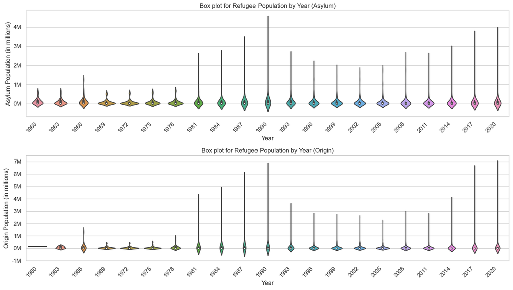

```python
import pandas as pd
import seaborn as sns
import matplotlib.pyplot as plt
from matplotlib.ticker import FuncFormatter


years = [str(year) for year in range(1960, 2023, 3)]
asylum_years = countryByAsylum[years]
origin_years = countryByOrigin[years]

# Filter out rows where 'Asylum Population' is 0
asylum_melted = asylum_years.melt(var_name='Year', value_name='Asylum Population')
asylum_melted = asylum_melted[asylum_melted['Asylum Population'] != 0]

# Filter out rows where 'Origin Population' is 0
origin_melted = origin_years.melt(var_name='Year', value_name='Origin Population')
origin_melted = origin_melted[origin_melted['Origin Population'] != 0]

# Function to format y-axis ticks in millions
def millions_formatter(x, pos):
    return f'{x / 1e6:.0f}M'

# Create subplots with two box plots for asylum and origin populations
plt.figure(figsize=(14, 8))

plt.subplot(2, 1, 1)
sns.violinplot(x='Year', y='Asylum Population', data=asylum_melted, whis=(0, 100))
plt.title('Box plot for Refugee Population by Year (Asylum)')
plt.xlabel('Year')
plt.ylabel('Asylum Population (in millions)')
plt.xticks(rotation=45, ha='right')  # Rotate x-axis labels for better readability
plt.gca().yaxis.set_major_formatter(FuncFormatter(millions_formatter))

plt.subplot(2, 1, 2)
sns.violinplot(x='Year', y='Origin Population', data=origin_melted, whis=(0, 100))
plt.title('Box plot for Refugee Population by Year (Origin)')
plt.xlabel('Year')
plt.ylabel('Origin Population (in millions)')
plt.xticks(rotation=45, ha='right')  # Rotate x-axis labels for better readability
plt.gca().yaxis.set_major_formatter(FuncFormatter(millions_formatter))

plt.tight_layout()
plt.show()
```

The box plot suggests that refugees in this year primarily originated from a single location, rather than being dispersed across various regions. This conclusion is based on the significant difference between the maximum value and the other quartiles (Q1, median, Q3) in the box plot. The large gap between the maximum and other values indicates a concentration of refugees from one dominant source.

However, it's important to remember that box plots only provide a summary of the data. Further analysis or additional information might be necessary to definitively confirm the origin of the majority of refugees.

# Countries Code of respective Group

eu_countries = ['AUT', 'BEL', 'BGR', 'HRV', 'CYP', 'CZE', 'DNK', 'EST', 'FIN', 'FRA', 'DEU', 'GRC', 'HUN', 'IRL', 'ITA', 'LVA', 'LTU', 'LUX', 'MLT', 'NLD', 'POL', 'PRT', 'ROU', 'SVK', 'SVN', 'ESP', 'SWE'] arab_world_countries = ['ARB', 'DZA', 'BHR', 'DJI', 'EGY', 'IRQ', 'ISR', 'JOR', 'KWT', 'LBN', 'LBY', 'MAR', 'OMN', 'PSE', 'QAT', 'SAU', 'SDN', 'SYR', 'TUN', 'YEM'] asean_countries = ['BRN', 'KHM', 'IDN', 'LAO', 'MYS', 'MMR', 'PHL', 'SGP', 'THA', 'VNM']

# EU Analysis of Refugee Asylum and Originated

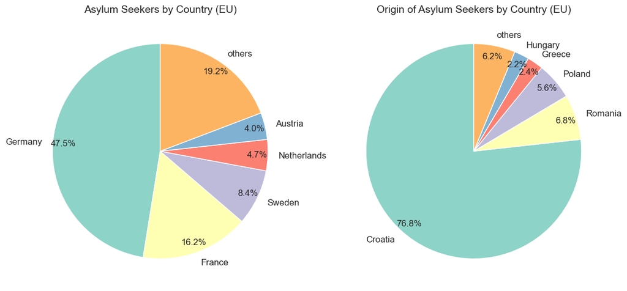

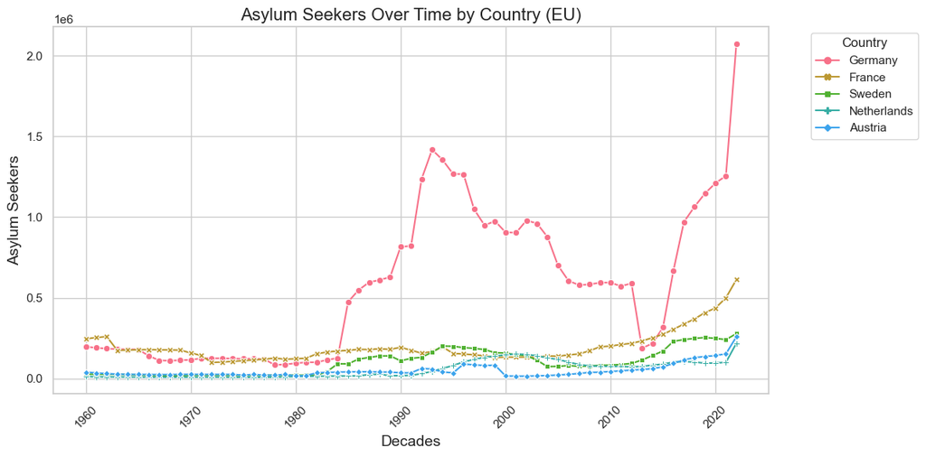

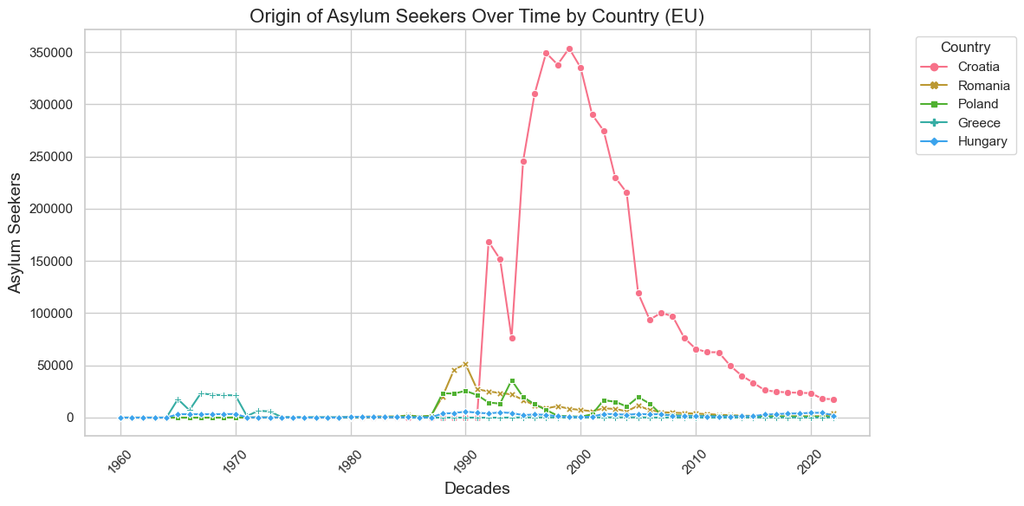

```python
import pandas as pd
import seaborn as sns
import matplotlib.pyplot as plt
import numpy as np

# Subset DataFrames for EU countries
eu_asylum = dfAsylum[dfAsylum["Country Code"].isin(eu_countries)].copy()
eu_origin = dfOrigin[dfOrigin["Country Code"].isin(eu_countries)].copy()

# Set "Country Name" as the index
eu_asylum.set_index("Country Name", inplace=True)
eu_origin.set_index("Country Name", inplace=True)

# Dropping specified columns in eu_asylum and eu_origin
columns_to_drop = ['Country Code', 'Indicator Name', 'Indicator Code']
eu_asylum.drop(columns=columns_to_drop, inplace=True)
eu_origin.drop(columns=columns_to_drop, inplace=True)

# Fill NaN values with 0 in eu_asylum
eu_asylum.fillna(0, inplace=True)
eu_origin.fillna(0, inplace=True)

# Sum of each row in eu_asylum
sum_by_country_asylum = eu_asylum.sum(axis=1)

# Sort eu_asylum by the sum of values in descending order
sorted_index_asylum = sum_by_country_asylum.sort_values(ascending=False).index
eu_asylum_sorted = eu_asylum.loc[sorted_index_asylum[:5]]

# Sum of each row in eu_origin
sum_by_country_origin = eu_origin.sum(axis=1)

# Sort eu_origin by the sum of values in descending order
sorted_index_origin = sum_by_country_origin.sort_values(ascending=False).index
eu_origin_sorted = eu_origin.loc[sorted_index_origin[:5]]

# Sort eu_asylum by the sum of values in descending order
sum_by_country_asylum = sum_by_country_asylum.loc[sum_by_country_asylum.sort_values(ascending=False).index]

# Create a new row for aggregated values of countries other than the top 5
new_row_asylum = pd.Series({
    'others': sum_by_country_asylum[5:].sum()
}, name='others')

# Concatenate the top 5 countries and the new row
sum_by_country_asylum = pd.concat([sum_by_country_asylum[:5], new_row_asylum])

# Sort eu_origin by the sum of values in descending order
sum_by_country_origin = sum_by_country_origin.loc[sum_by_country_origin.sort_values(ascending=False).index]

# Create a new row for aggregated values of countries other than the top 5
new_row_origin = pd.Series({
    'others': sum_by_country_origin[5:].sum()
}, name='others')

# Concatenate the top 5 countries and the new row
sum_by_country_origin = pd.concat([sum_by_country_origin[:5], new_row_origin])


# Plotting side-by-side pie charts with improved aesthetics
fig, axs = plt.subplots(1, 2, figsize=(12, 6))

# Pie chart for asylum
axs[0].pie(sum_by_country_asylum, labels=sum_by_country_asylum.index, autopct='%1.1f%%',pctdistance=0.9, startangle=90,
           colors=sns.color_palette('Set3'), textprops={'fontsize': 12})
axs[0].set_title('Asylum Seekers by Country (EU)', fontsize=14)

# Pie chart for origin
axs[1].pie(sum_by_country_origin, labels=sum_by_country_origin.index, autopct='%1.1f%%',pctdistance=0.9, startangle=90,
           colors=sns.color_palette('Set3'), textprops={'fontsize': 12})
axs[1].set_title('Origin of Asylum Seekers by Country (EU)', fontsize=14)


plt.tight_layout()
plt.show()

# Filter time columns based on sorted indices
time_columns_asylum = eu_asylum_sorted.columns
time_columns_origin = eu_origin_sorted.columns

# Convert the time columns to datetime objects
eu_asylum_sorted[time_columns_asylum] = eu_asylum_sorted[time_columns_asylum].astype(int)
eu_origin_sorted[time_columns_origin] = eu_origin_sorted[time_columns_origin].astype(int)

# Plotting line chart for asylum
plt.figure(figsize=(12, 6))
sns.set(style="whitegrid", palette="husl")  # Adjusted color palette

sns.lineplot(data=eu_asylum_sorted.T, markers=True, dashes=False)
plt.title('Asylum Seekers Over Time by Country (EU)', fontsize=16)
plt.xlabel('Decades', fontsize=14)
plt.ylabel('Asylum Seekers', fontsize=14)

# Set x ticks by decade
plt.xticks(range(0, len(eu_asylum_sorted.columns), 10), labels=eu_asylum_sorted.columns[::10], rotation=45)

plt.legend(title='Country', bbox_to_anchor=(1.05, 1), loc='upper left')
plt.tight_layout()  # Improved layout
plt.show()

# Plotting line chart for origin
plt.figure(figsize=(12, 6))
sns.set(style="whitegrid", palette="husl")  # Adjusted color palette

sns.lineplot(data=eu_origin_sorted.T, markers=True, dashes=False)
plt.title('Origin of Asylum Seekers Over Time by Country (EU)', fontsize=16)
plt.xlabel('Decades', fontsize=14)
plt.ylabel('Asylum Seekers', fontsize=14)

# Set x ticks by decade
plt.xticks(range(0, len(eu_origin_sorted.columns), 10), labels=eu_origin_sorted.columns[::10], rotation=45)

plt.legend(title='Country', bbox_to_anchor=(1.05, 1), loc='upper left')
plt.tight_layout()  # Improved layout
plt.show()
```

# EU analysis

The obtained data suggests that Croatia stands out as the primary source of refugees among EU countries, constituting more than three-quarters of the total. My research indicates that this is largely attributable to Croatia's declaration of independence from the former Yugoslavia in 1991, leading to a protracted war lasting until 1995. Throughout this period, approximately 900,000 Croats experienced displacement, both internally and externally.

One significant event contributing to this phenomenon was the exodus of an estimated 200,000 to 300,000 ethnic Serbs from Croatia in August 1995, following a military conflict. Simultaneously, around 130,000 ethnic Croats departed Bosnia and Herzegovina for Croatia. In terms of the recipient country for refugee asylum, Germany emerges as a major contributor, accounting for nearly half of the total.

Moreover, due to the Ukrainian War, there has been a noticeable increase in refugees seeking asylum in EU countries. This upward trend is evident in the line chart, particularly towards the end, depicting a steady rise in numbers over time.

Ref. Project, B. (2020) 10 important facts to know about Croatian refugees, The Borgen Project. Available at: https://borgenproject.org/10-facts-about-croatian-refugees/ (Accessed: 02 February 2024).

# ARAB WORLD Analysis of Refugee Asylum and Originated

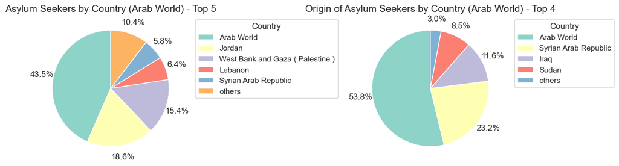

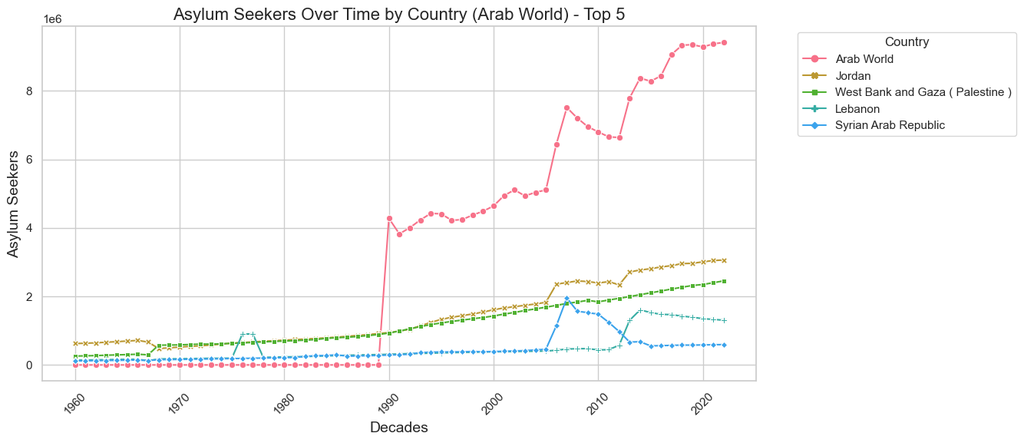

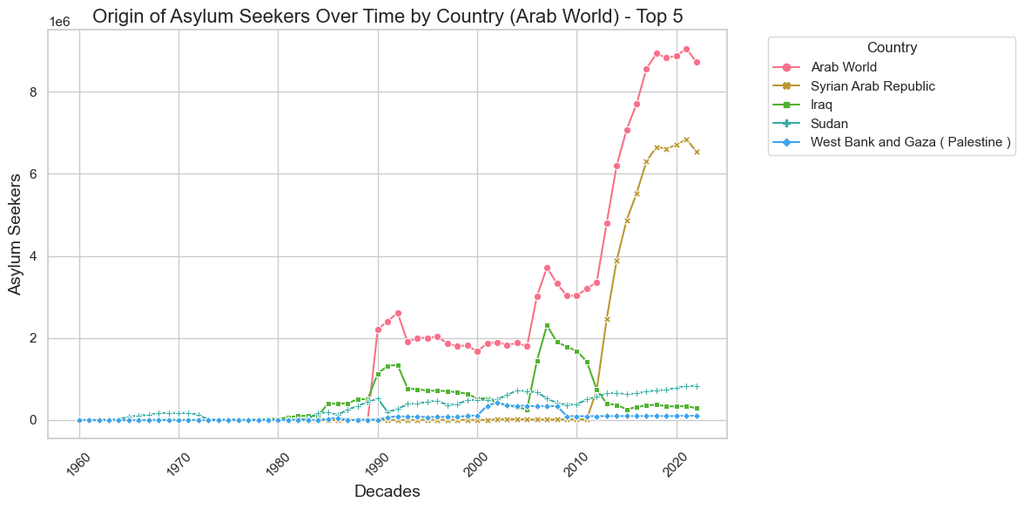

```python
import pandas as pd
import seaborn as sns
import matplotlib.pyplot as plt

# Country codes for Arab World
arab_world_countries = ['ARB', 'DZA', 'BHR', 'DJI', 'EGY', 'IRQ', 'ISR', 'JOR', 'KWT', 'LBN', 'LBY', 'MAR', 'OMN', 'PSE', 'QAT', 'SAU', 'SDN', 'SYR', 'TUN', 'YEM']

# Subset DataFrames for Arab World countries
arab_asylum = dfAsylum[dfAsylum["Country Code"].isin(arab_world_countries)].copy()
arab_origin = dfOrigin[dfOrigin["Country Code"].isin(arab_world_countries)].copy()

# Set "Country Name" as the index
arab_asylum.set_index("Country Name", inplace=True)
arab_origin.set_index("Country Name", inplace=True)

# Dropping specified columns in arab_asylum and arab_origin
columns_to_drop = ['Country Code', 'Indicator Name', 'Indicator Code']
arab_asylum.drop(columns=columns_to_drop, inplace=True)
arab_origin.drop(columns=columns_to_drop, inplace=True)

# Fill NaN values with 0 in arab_asylum
arab_asylum.fillna(0, inplace=True)
arab_origin.fillna(0, inplace=True)

# Sum of each row in arab_asylum
sum_by_country_asylum = arab_asylum.sum(axis=1)

# Sort arab_asylum by the sum of values in descending order
sorted_index_asylum = sum_by_country_asylum.sort_values(ascending=False).index
arab_asylum_sorted = arab_asylum.loc[sorted_index_asylum[:5]]

# Sum of each row in arab_origin
sum_by_country_origin = arab_origin.sum(axis=1)

# Sort arab_origin by the sum of values in descending order
sorted_index_origin = sum_by_country_origin.sort_values(ascending=False).index
arab_origin_sorted = arab_origin.loc[sorted_index_origin[:5]]

# Sort arab_asylum by the sum of values in descending order
sum_by_country_asylum = sum_by_country_asylum.loc[sum_by_country_asylum.sort_values(ascending=False).index]

# Create a new row for aggregated values of countries other than the top 5
new_row_asylum = pd.Series({
    'others': sum_by_country_asylum[5:].sum()
}, name='others')

# Concatenate the top 5 countries and the new row
sum_by_country_asylum = pd.concat([sum_by_country_asylum[:5], new_row_asylum])

# Sort arab_origin by the sum of values in descending order
sum_by_country_origin = sum_by_country_origin.loc[sum_by_country_origin.sort_values(ascending=False).index]

# Create a new row for aggregated values of countries other than the top 4
new_row_origin = pd.Series({
    'others': sum_by_country_origin[4:].sum()
}, name='others')

# Concatenate the top 4 countries and the new row
sum_by_country_origin = pd.concat([sum_by_country_origin[:4], new_row_origin])

# Plotting side-by-side pie charts with improved aesthetics and legend
fig, axs = plt.subplots(1, 2, figsize=(12, 6))

# Pie chart for asylum
asylum_pie = axs[0].pie(sum_by_country_asylum, labels=None, autopct='%1.1f%%', pctdistance=1.2, startangle=90,
                         colors=sns.color_palette('Set3'))
axs[0].set_title('Asylum Seekers by Country (Arab World) - Top 5', fontsize=14)

# Pie chart for origin
origin_pie = axs[1].pie(sum_by_country_origin, labels=None, autopct='%1.1f%%', pctdistance=1.2, startangle=90,
                         colors=sns.color_palette('Set3'))
axs[1].set_title('Origin of Asylum Seekers by Country (Arab World) - Top 4', fontsize=14)

# Add legends
axs[0].legend(asylum_pie[0], sum_by_country_asylum.index, title='Country', bbox_to_anchor=(1.05, 1), loc='upper left')
axs[1].legend(origin_pie[0], sum_by_country_origin.index, title='Country', bbox_to_anchor=(1.05, 1), loc='upper left')

plt.tight_layout()
plt.show()

# Filter time columns based on sorted indices
time_columns_asylum = arab_asylum_sorted.columns
time_columns_origin = arab_origin_sorted.columns

# Convert the time columns to datetime objects
arab_asylum_sorted[time_columns_asylum] = arab_asylum_sorted[time_columns_asylum].astype(int)
arab_origin_sorted[time_columns_origin] = arab_origin_sorted[time_columns_origin].astype(int)

# Plotting line chart for asylum
plt.figure(figsize=(12, 6))
sns.set(style="whitegrid", palette="husl")  # Adjusted color palette

sns.lineplot(data=arab_asylum_sorted.T, markers=True, dashes=False)
plt.title('Asylum Seekers Over Time by Country (Arab World) - Top 5', fontsize=16)
plt.xlabel('Decades', fontsize=14)
plt.ylabel('Asylum Seekers', fontsize=14)

# Set x ticks by decade
plt.xticks(range(0, len(arab_asylum_sorted.columns), 10), labels=arab_asylum_sorted.columns[::10], rotation=45)

plt.legend(title='Country', bbox_to_anchor=(1.05, 1), loc='upper left')
plt.show()

# Plotting line chart for origin
plt.figure(figsize=(12, 6))
sns.set(style="whitegrid", palette="husl")  # Adjusted color palette

sns.lineplot(data=arab_origin_sorted.T, markers=True, dashes=False)
plt.title('Origin of Asylum Seekers Over Time by Country (Arab World) - Top 5', fontsize=16)
plt.xlabel('Decades', fontsize=14)
plt.ylabel('Asylum Seekers', fontsize=14)

# Set x ticks by decade
plt.xticks(range(0, len(arab_origin_sorted.columns), 10), labels=arab_origin_sorted.columns[::10], rotation=45)

plt.legend(title='Country', bbox_to_anchor=(1.05, 1), loc='upper left')
plt.tight_layout()  # Improved layout
plt.show()
```